# Check candidate probes on 0020227

To the extent that selected genes are present on existing xenium panel, how do they perform on dataset in practice. Here we will define practical utility as detected and differential expression across clusters after processing xenium data. Clusters are intentionally and explicitly unnamed.

# Environment

```r
library(Seurat)
library(tidyverse)
```

# Prepare xenium dataset

```r
ipf3.xen <- LoadXenium('output-XETG00143__0020227__Region_1__20231214__022306/')
```

## Routine filter

```r
ipf3.filtered.xen <- subset(ipf3.xen, subset=nCount_Xenium>20 & nFeature_Xenium>4)
print('original dataset:')
print(ncol(ipf3.xen))
print('filtered dataset:')
print(ncol(ipf3.filtered.xen))
```

[output not shown]

```r
# housekeeping, never enough
rm(ipf3.xen)
gc()
```

## Routine clustering

```r
ipf3.filtered.xen <- FindClusters(ipf3.filtered.xen, resolution = 1)
```

```
Modularity Optimizer version 1.3.0 by Ludo Waltman and Nees Jan van Eck

Number of nodes: 158303
Number of edges: 34332922

Running Louvain algorithm...
Maximum modularity in 10 random starts: 0.8172
Number of communities: 22
Elapsed time: 391 seconds
```

## Routine sanity checks

```
Rasterizing points since number of points exceeds 100,000.
To disable this behavior set `raster=FALSE`
```

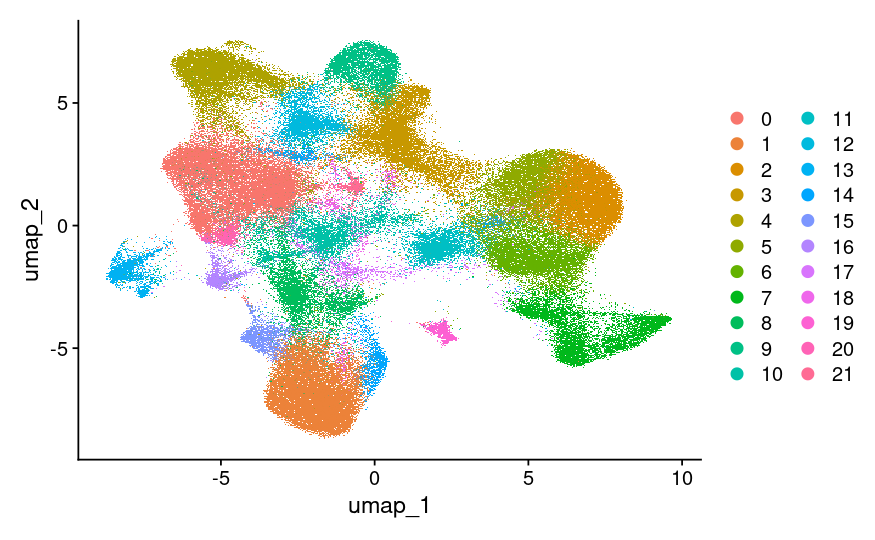

```r
DimPlot(ipf3.filtered.xen)
```

[output not shown]

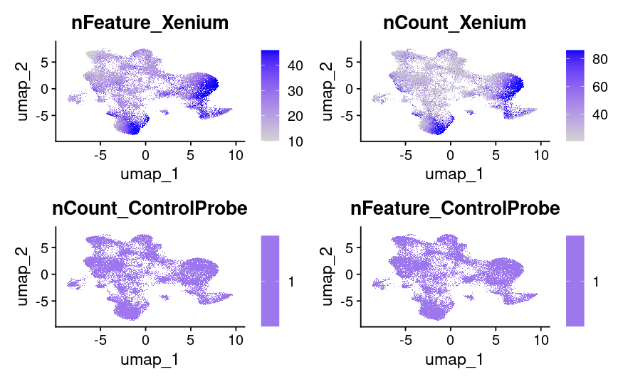

```r
FeaturePlot(ipf3.filtered.xen, features = c("nFeature_Xenium", "nCount_Xenium", "nCount_ControlProbe", "nFeature_ControlProbe"), min.cutoff='q1', max.cutoff='q90')
```

```
Rasterizing points since number of points exceeds 100,000.
To disable this behavior set `raster=FALSE`
Rasterizing points since number of points exceeds 100,000.
To disable this behavior set `raster=FALSE`
Rasterizing points since number of points exceeds 100,000.
To disable this behavior set `raster=FALSE`
Rasterizing points since number of points exceeds 100,000.
To disable this behavior set `raster=FALSE`
```

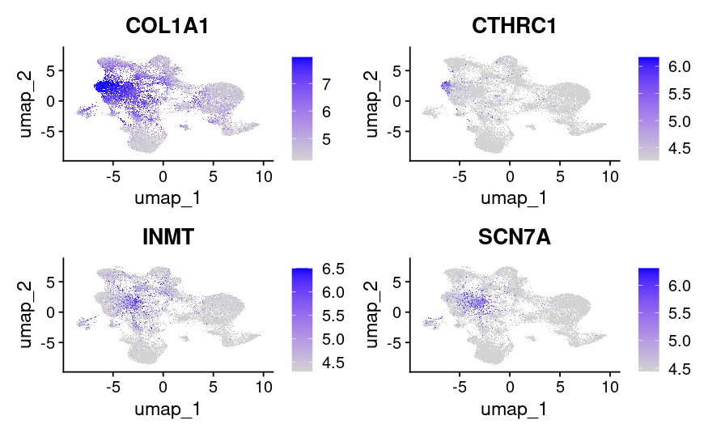

```r
FeaturePlot(ipf3.filtered.xen, features = c("COL1A1", "CTHRC1", "INMT", "SCN7A"), min.cutoff='q1', max.cutoff='q90')
```

```
Rasterizing points since number of points exceeds 100,000.
To disable this behavior set `raster=FALSE`
Rasterizing points since number of points exceeds 100,000.
To disable this behavior set `raster=FALSE`
Rasterizing points since number of points exceeds 100,000.
To disable this behavior set `raster=FALSE`
Rasterizing points since number of points exceeds 100,000.
To disable this behavior set `raster=FALSE`
```

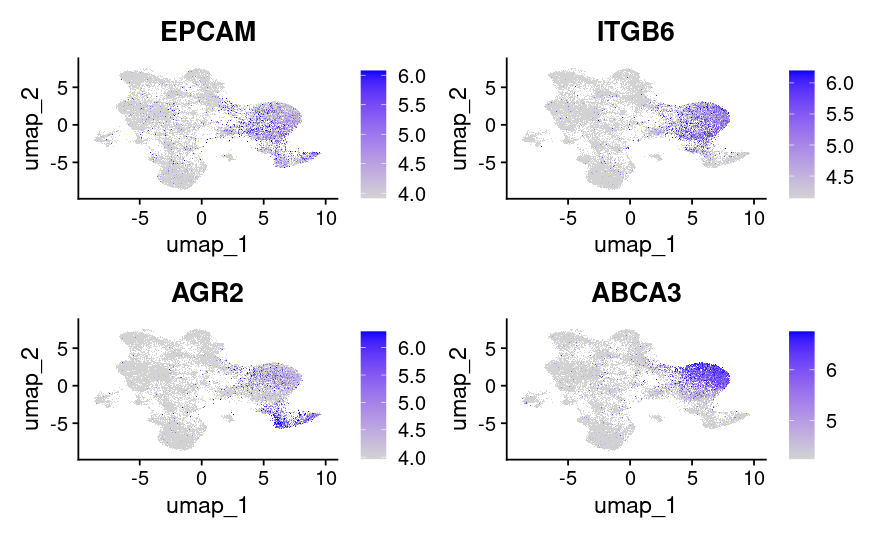

```r
FeaturePlot(ipf3.filtered.xen, features = c("EPCAM", "ITGB6", "AGR2", "ABCA3"), min.cutoff='q1', max.cutoff='q90')
```

# Evaluate expressed, highly-variable genes

Analysis for this table was performed in the Probeset Performance notebook.

```r
probesets_xeniumperformance <- read_csv(file='probesets_xeniumperformance.csv')
```

Filter this for those genes which are highly variable across cells, and have some threshold detection rate in filtered cells. See Probeset Performance notebook. Genes not included in this list are not uninformative, but these genes would be definitely useful. Notable genes that did not make these cutoffs are ones like COL1A1, because while variance is high, it is not particularly high after adjusting for expression level.

```r
probesets_xeniumperformance %>% filter(xeniumAvg > 1.35) %>% filter(variance.standardized > 1.20) -> probesets_selected
```

[figure not shown]

Unfortunately this heatmap is alphabetically ordered so it is a bit of a pain in the ass to interpret. For cell-based heatmaps, a lot of trouble getting 100k cells to display correctly, export directly to file.

```r
p <- DoHeatmap(ipf3.filtered.xen, features=probesets_selected$gene)
ggsave(filename='plot.png', plot=p, device='png', width=30, height=15)
```

# Evaluate candidate probesets from Tatsuya

```r
probesets_fibroblastproposed <- read_csv(file='fibroblastmarkers_20240201.csv')
probesets_selected <- probesets_fibroblastproposed$Gene
```

[figure not shown]

For cell-based heatmaps, a lot of trouble getting 100k cells to display correctly, export directly to file.

```r
p <- DoHeatmap(ipf3.filtered.xen, features=probesets_selected)
ggsave(filename='plot.png', plot=p, device='png', width=20, height=5)
```

```r
p <- DoHeatmap(ipf3.filtered.xen, features=probesets_selected, slot='data')
ggsave(filename='plot.png', plot=p, device='png', width=20, height=5)
```

```r
p <- DoHeatmap(ipf3.filtered.xen, features=probesets_selected, slot='counts')
ggsave(filename='plot.png', plot=p, device='png', width=20, height=5)
```

Generate umap embeddings for every gene here.

```
Rasterizing points since number of points exceeds 100,000.
To disable this behavior set `raster=FALSE`
Rasterizing points since number of points exceeds 100,000.
To disable this behavior set `raster=FALSE`
Rasterizing points since number of points exceeds 100,000.
To disable this behavior set `raster=FALSE`
Rasterizing points since number of points exceeds 100,000.
To disable this behavior set `raster=FALSE`
```

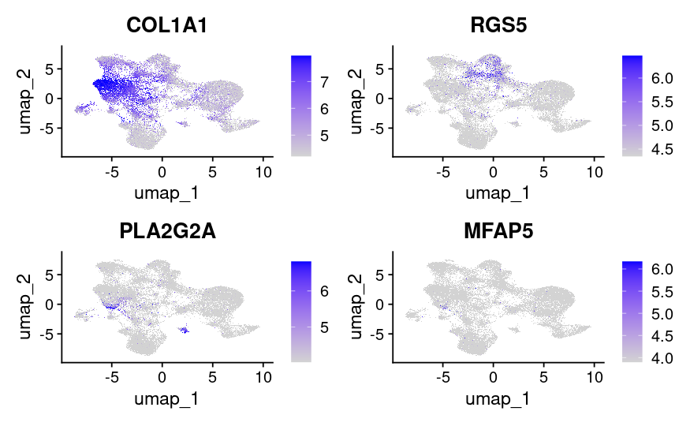

```r
FeaturePlot(ipf3.filtered.xen, features = c("COL1A1", "RGS5", "PLA2G2A", "MFAP5"), min.cutoff='q1', max.cutoff='q90')
```

```
Rasterizing points since number of points exceeds 100,000.
To disable this behavior set `raster=FALSE`
Rasterizing points since number of points exceeds 100,000.
To disable this behavior set `raster=FALSE`
Rasterizing points since number of points exceeds 100,000.
To disable this behavior set `raster=FALSE`
Rasterizing points since number of points exceeds 100,000.
To disable this behavior set `raster=FALSE`
```

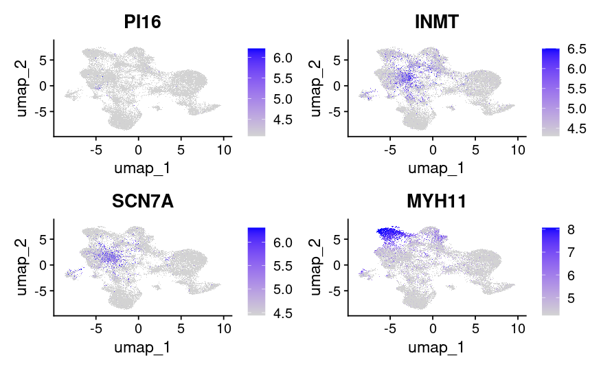

```r
FeaturePlot(ipf3.filtered.xen, features = c("PI16", "INMT", "SCN7A", "MYH11"), min.cutoff='q1', max.cutoff='q90')
```

```
Rasterizing points since number of points exceeds 100,000.
To disable this behavior set `raster=FALSE`
Rasterizing points since number of points exceeds 100,000.
To disable this behavior set `raster=FALSE`
Rasterizing points since number of points exceeds 100,000.
To disable this behavior set `raster=FALSE`
Rasterizing points since number of points exceeds 100,000.
To disable this behavior set `raster=FALSE`
```

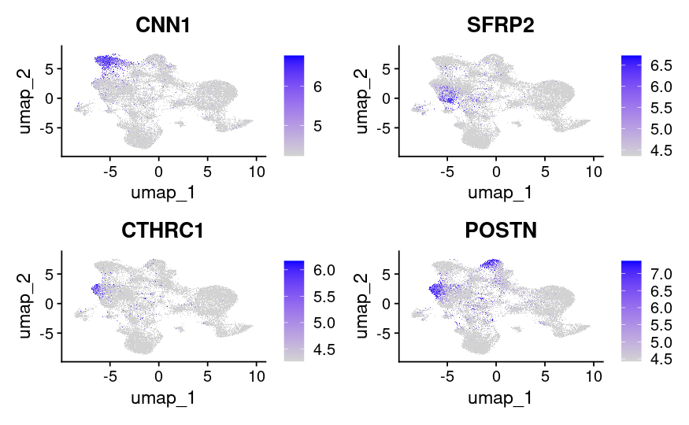

```r
FeaturePlot(ipf3.filtered.xen, features = c("CNN1", "SFRP2", "CTHRC1", "POSTN"), min.cutoff='q1', max.cutoff='q90')
```

```
Rasterizing points since number of points exceeds 100,000.
To disable this behavior set `raster=FALSE`
Rasterizing points since number of points exceeds 100,000.
To disable this behavior set `raster=FALSE`
Rasterizing points since number of points exceeds 100,000.
To disable this behavior set `raster=FALSE`
Rasterizing points since number of points exceeds 100,000.
To disable this behavior set `raster=FALSE`
```

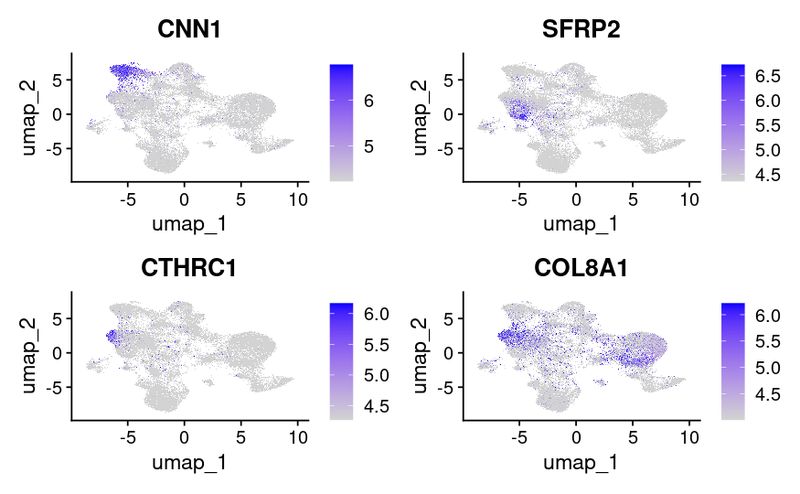

```r
FeaturePlot(ipf3.filtered.xen, features = c("CNN1", "SFRP2", "CTHRC1", "COL8A1"), min.cutoff='q1', max.cutoff='q90')
```